# Data Reanalysis of Wang et al. (2018)

Kevin Sanchez

4/16/2020

## Introduction

### Wang et al. (2018) — 17β-estradiol (E2) promotes growth and stability of new dendritic spines via estrogen receptor β pathway in intact mouse cortex

Recent studies have found that altering levels of estradiol (E2), the most potent estrogen, can affect neuronal function in several brain regions like the hippocampus and prefrontal cortex. One potential mechanism is through modulation of dendritic spine density in these brain regions, which can impact advanced cognitive functions like learning and memory. The objective of this paper is to quantify how E2 treatment can alter the growth and removal of these dendritic spines. Additionally, the authors wanted to investigate which of the two estrogen receptors (ERs), ERα and ERβ, are involved in mediating this process. They used the ER agonists α-PPT and β-DPN to enhance the activity of ERα and ERβ, respectively.

Their raw data is stratified into two discrete time periods where they observed changes in dendritic spines: 0-4 days (d4) and 4-8 days (d8). For some analyses, they used the combination of these time periods from 0-8 days (dT). The raw data quantifies the total number of dendritic spines initially observed (d#_total) and the number of spines that were stable, eliminated, or formed after the time period described (d#_stable, d#_elim, d#_form, respectively).

The analyses performed by the authors include descriptive statistics for each of the parameters described above, including the mean, standard deviation, and standard error of the mean. To determine if there were differences between experimental groups, the authors employed a t-test. All of their data were graphed as bar graphs.

In this assignment, I will be replicating most of the descriptive statistics that the authors performed. Using their data comparing dendritic spine characteristics between the control and E2-treated mice, I will redo their t-test and compare it to the authors’ results. Lastly, I will recreate the three graphs from Figure 2 of their paper.

## Visualization of Data

First, I will load in the raw data files in .xlsx format using the package {readxl}.

```r
library(readxl)
file <- "Wang et al. (2018) Raw Data.xlsx"
rawdata <- read_excel(file, sheet = 1, col_names = TRUE)
```

Using `head()` will confirm that the data set was imported into *R* correctly. The `names()` function is also useful in providing all the header names that will be used in subsequent analyses.

```r
head(rawdata)
```

```
## # A tibble: 6 x 17
##   Exp_Group Animal_ID d4_total d4_stable d4_elim d4_form d8_total d8_stable
##   <chr>     <chr>        <dbl>     <dbl>   <dbl>   <dbl>    <dbl>     <dbl>
## 1 WT1       gf040          118       111       7       6       NA        NA
## 2 WT1       w134           133       123      10       2      125       119
## 3 WT1       w039           121       110      11       6      116       111
## 4 WT1       w040           132       121      11       6      127       116
## 5 WT1       w129           149       135      14       8      143       130
## 6 WT1       w119F          124       116       8       8      124       117
## # … with 9 more variables: d8_elim <dbl>, d8_form <dbl>, dT_total <dbl>,
## #   dT_stable <dbl>, dT_elim <dbl>, dT_form <dbl>, d4_nfs_pers <dbl>,
## #   d4_nfs_lost <dbl>, d4_elim_return <dbl>
```

```r
names(rawdata)
```

```
##  [1] "Exp_Group"      "Animal_ID"      "d4_total"       "d4_stable"
##  [5] "d4_elim"        "d4_form"        "d8_total"       "d8_stable"
##  [9] "d8_elim"        "d8_form"        "dT_total"       "dT_stable"
## [13] "dT_elim"        "dT_form"        "d4_nfs_pers"    "d4_nfs_lost"
## [17] "d4_elim_return"
```

Next, I will filter the entire data set based on experimental group using `filter()` from {dplyr}. This will yield five new tables that can be easily used for comparison of variables between experimental groups. Note that the authors of the paper state that the wild-type 1 (WT1) group is used for comparisons with the E2 group and that the wild-type 2 (WT2) group is used to compare with the DPN and PPT groups.

```r
library(dplyr)
WT1 <- filter(rawdata, rawdata$Exp_Group == "WT1")
E2 <- filter(rawdata, rawdata$Exp_Group == "E2")
WT2 <- filter(rawdata, rawdata$Exp_Group == "WT2")
DPN <- filter(rawdata, rawdata$Exp_Group == "DPN")
PPT <- filter(rawdata, rawdata$Exp_Group == "PPT")
```

Now that I have these filtered data sets, I can draw both basic and more sophisticated comparisons between experimental groups. For example, let’s compare the means of the total dendritic spines (**dT_total**). Other studies have demonstrated that treatment with E2 increases spine density; therefore, I would expect to have a higher value of **dT_total** in the E2 group compared to the WT1 group.

```r
mean(WT1$dT_total, na.rm = TRUE)
```

```
## [1] 132.5
```

```r
mean(E2$dT_total, na.rm = TRUE)
```

```
## [1] 147
```

Although I cannot claim statistical significance at this stage of the analysis, it does appear that the E2 group has a higher density of dendritic spines compared with WT1. I can more broadly see an overview of each variable and its five-number summary using the `summary()` function. Let’s do this with just the **WT1** and **E2** data sets.

```r
summary(WT1)
```

```
##   Exp_Group          Animal_ID            d4_total       d4_stable
##  Length:7           Length:7           Min.   :118.0   Min.   :110.0
##  Class :character   Class :character   1st Qu.:122.5   1st Qu.:113.5
##  Mode  :character   Mode  :character   Median :132.0   Median :121.0
##                                        Mean   :130.4   Mean   :119.7
##                                        3rd Qu.:134.5   3rd Qu.:122.5
##                                        Max.   :149.0   Max.   :135.0
##
##     d4_elim         d4_form     d8_total       d8_stable        d8_elim
##  Min.   : 7.00   Min.   :2   Min.   :116.0   Min.   :111.0   Min.   : 5.000
##  1st Qu.: 9.00   1st Qu.:6   1st Qu.:124.2   1st Qu.:115.2   1st Qu.: 6.250
##  Median :11.00   Median :6   Median :126.0   Median :116.5   Median : 9.000
##  Mean   :10.71   Mean   :6   Mean   :127.2   Mean   :118.0   Mean   : 9.167
##  3rd Qu.:12.50   3rd Qu.:7   3rd Qu.:127.8   3rd Qu.:118.5   3rd Qu.:12.500
##  Max.   :14.00   Max.   :8   Max.   :143.0   Max.   :130.0   Max.   :13.000
##                              NA's   :1       NA's   :1       NA's   :1
##     d8_form         dT_total       dT_stable        dT_elim         dT_form
##  Min.   : 2.00   Min.   :121.0   Min.   :112.0   Min.   : 8.00   Min.   :6.0
##  1st Qu.: 3.75   1st Qu.:126.0   1st Qu.:113.0   1st Qu.:11.50   1st Qu.:6.0
##  Median : 6.50   Median :132.5   Median :114.5   Median :14.50   Median :6.0
##  Mean   : 6.00   Mean   :132.5   Mean   :117.3   Mean   :15.17   Mean   :6.5
##  3rd Qu.: 7.75   3rd Qu.:135.2   3rd Qu.:119.0   3rd Qu.:18.25   3rd Qu.:6.0
##  Max.   :10.00   Max.   :149.0   Max.   :130.0   Max.   :24.00   Max.   :9.0
##  NA's   :1       NA's   :1       NA's   :1       NA's   :1       NA's   :1
##   d4_nfs_pers    d4_nfs_lost   d4_elim_return
##  Min.   :0.00   Min.   :2.00   Min.   :0.000
##  1st Qu.:2.25   1st Qu.:2.25   1st Qu.:1.250
##  Median :3.00   Median :3.50   Median :2.000
##  Mean   :2.50   Mean   :3.50   Mean   :2.333
##  3rd Qu.:3.00   3rd Qu.:4.75   3rd Qu.:2.750
##  Max.   :4.00   Max.   :5.00   Max.   :6.000
##  NA's   :1      NA's   :1      NA's   :1
```

```r
summary(E2)
```

```
##   Exp_Group          Animal_ID            d4_total       d4_stable
##  Length:9           Length:9           Min.   :132.0   Min.   :119.0
##  Class :character   Class :character   1st Qu.:144.0   1st Qu.:132.0
##  Mode  :character   Mode  :character   Median :148.0   Median :141.0
##                                        Mean   :147.2   Mean   :137.7
##                                        3rd Qu.:153.0   3rd Qu.:143.0
##                                        Max.   :165.0   Max.   :156.0
##     d4_elim          d4_form          d8_total       d8_stable        d8_elim
##  Min.   : 7.000   Min.   : 6.000   Min.   :131.0   Min.   :121.0   Min.   : 7
##  1st Qu.: 9.000   1st Qu.: 8.000   1st Qu.:141.0   1st Qu.:131.0   1st Qu.: 9
##  Median : 9.000   Median :10.000   Median :147.0   Median :140.0   Median : 9
##  Mean   : 9.444   Mean   : 9.444   Mean   :147.2   Mean   :138.2   Mean   : 9
##  3rd Qu.:10.000   3rd Qu.:11.000   3rd Qu.:153.0   3rd Qu.:144.0   3rd Qu.:10
##  Max.   :13.000   Max.   :12.000   Max.   :167.0   Max.   :158.0   Max.   :10
##     d8_form          dT_total     dT_stable        dT_elim         dT_form
##  Min.   : 1.000   Min.   :132   Min.   :117.0   Min.   :11.00   Min.   : 5.00
##  1st Qu.: 6.000   1st Qu.:144   1st Qu.:126.0   1st Qu.:12.00   1st Qu.:11.00
##  Median : 7.000   Median :148   Median :135.0   Median :13.00   Median :13.00
##  Mean   : 7.222   Mean   :147   Mean   :133.6   Mean   :13.44   Mean   :11.89
##  3rd Qu.: 9.000   3rd Qu.:151   3rd Qu.:139.0   3rd Qu.:15.00   3rd Qu.:13.00
##  Max.   :14.000   Max.   :165   Max.   :153.0   Max.   :18.00   Max.   :18.00
##   d4_nfs_pers     d4_nfs_lost    d4_elim_return
##  Min.   :5.000   Min.   :1.000   Min.   :0.000
##  1st Qu.:6.000   1st Qu.:2.000   1st Qu.:1.000
##  Median :6.000   Median :3.000   Median :2.000
##  Mean   :6.333   Mean   :3.111   Mean   :1.667
##  3rd Qu.:7.000   3rd Qu.:4.000   3rd Qu.:2.000
##  Max.   :8.000   Max.   :6.000   Max.   :3.000
```

This output makes it a little difficult to neatly draw comparisons between groups. I can compare the variable **dT_total** across all experimental groups by using the package {ggplot2} on the **rawdata** file.

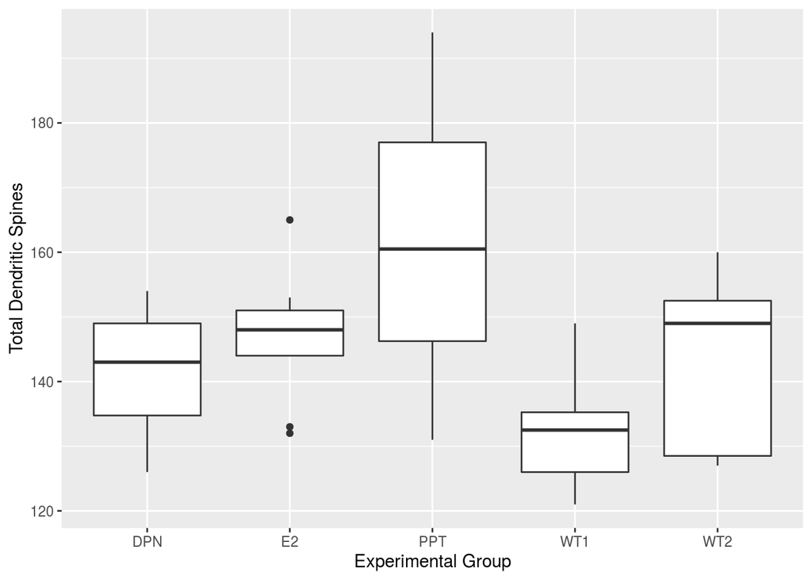

```r
library(ggplot2)
bp_dT_total <- ggplot(data = rawdata, aes(x = Exp_Group, y = dT_total)) +
  geom_boxplot(na.rm = TRUE) +
  theme(axis.text.x = element_text(angle = 0)) +
  xlab("Experimental Group") + ylab("Total Dendritic Spines")
bp_dT_total
```

Doing these box plots allows for neat visual comparisons between groups and for observing the variability within groups. Another method of data exploration includes using the package {psych} to determine correlations between several variables. I will first use the `select()` function of {dplyr} to condense the **rawdata** data set to include variables looking at dendritic spine characteristics across the 8 day experiment (i.e., **dT_total**, **dT_stable**, **dT_elim**, and **dT_form**. I will then pass this selected data set through the `pairs.panels()` function to create the scatter plot matrix of correlation between variables.

```r
library(psych)
```

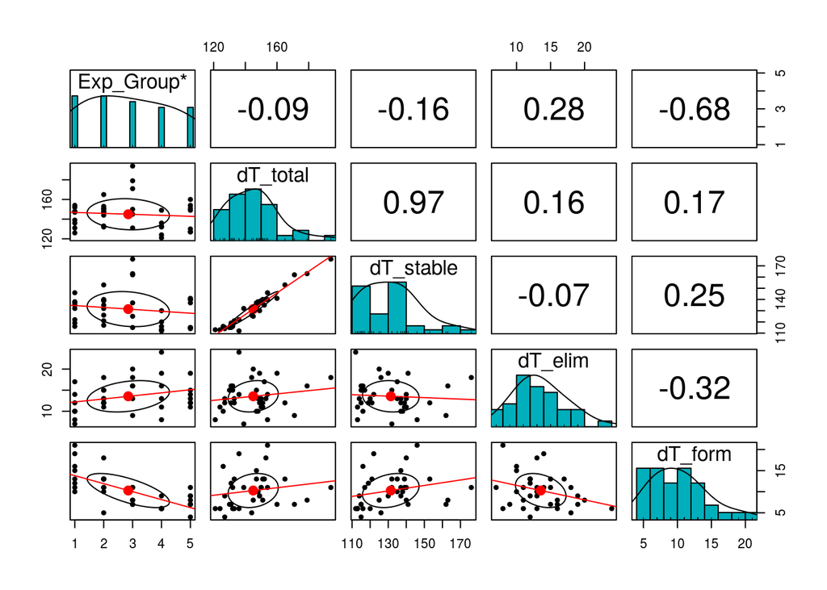

```r
rawdata_select <- select(rawdata, Exp_Group, dT_total, dT_stable, dT_elim, dT_form)
pairs.panels(rawdata_select[],
             smooth = FALSE,
             lm = TRUE,
             method = "pearson",
             hist.col = "#00AFBB",
             density = TRUE,
             ellipses = TRUE
)
```

From this scatter plot matrix, I can that there is a strong, positive correlation (r=0.97) between the total amount of dendritic spines and the number of stable, persistent spines. Now that I have done some exploratory data analysis, I will replicate some of the authors’ data, repeat their t-tests between experimental groups, and recreate the three graphs from Figure 2 of their paper.

## Replications and Reanalysis

To start, I will first reanalyze the describe statistics in Sections 2.2 and 2.3 of the paper. This entails quantifying how E2 treatment affects dendritic spine formation rate, total quantity of spines, and persistent newly formed spines. First, I will determine whether the spine formation rate is different between the WT1 and E2 groups during the 0-4, 4-8, or 0-8 day window. Spine formation rate (SFR) is determined as the number of newly formed spines (d#_form) divided by the the total number of spines (d#_total) multiplied by 100 to obtain the percentage. Below, I calculate the mean and standard error of the mean (i.e., standard deviation divided by the square root of counts) for the two groups at the different time points.

```r
print("SFR (Mean ± SEM) for WT Group Between Days 0-4")
```

```
## [1] "SFR (Mean ± SEM) for WT Group Between Days 0-4"
```

```r
(SFRm_WT_4 <- mean(WT1$d4_form / WT1$d4_total, na.rm = TRUE) * 100)
```

```
## [1] 4.617878
```

```r
(SFRs_WT_4 <- sd((WT1$d4_form / WT1$d4_total) * 100, na.rm = TRUE) / sqrt(length(WT1$d4_form)))
```

```
## [1] 0.5774849
```

```r
print("SFR (Mean ± SEM) for E2 Group Between Days 0-4")
```

```
## [1] "SFR (Mean ± SEM) for E2 Group Between Days 0-4"
```

```r
(SFRm_E2_4 <- mean(E2$d4_form / E2$d4_total, na.rm = TRUE) * 100)
```

```
## [1] 6.440878
```

```r
(SFRs_E2_4 <- sd((E2$d4_form / E2$d4_total) * 100, na.rm = TRUE) / sqrt(length(E2$d4_form)))
```

```
## [1] 0.5127345
```

```r
print("SFR (Mean ± SEM) for WT Group Between Days 4-8")
```

```
## [1] "SFR (Mean ± SEM) for WT Group Between Days 4-8"
```

```r
(SFRm_WT_8 <- mean(WT1$d8_form / WT1$d8_total, na.rm = TRUE) * 100)
```

```
## [1] 4.695104
```

```r
(SFRs_WT_8 <- sd((WT1$d8_form / WT1$d8_total) * 100, na.rm = TRUE) / sqrt(length(WT1$d8_form)))
```

```
## [1] 0.8614813
```

```r
print("SFR (Mean ± SEM) for E2 Group Between Days 4-8")
```

```
## [1] "SFR (Mean ± SEM) for E2 Group Between Days 4-8"
```

```r
(SFRm_E2_8 <- mean(E2$d8_form / E2$d8_total, na.rm = TRUE) * 100)
```

```
## [1] 4.86972
```

```r
(SFRs_E2_8 <- sd((E2$d8_form / E2$d8_total) * 100, na.rm = TRUE) / sqrt(length(E2$d8_form)))
```

```
## [1] 0.7609529
```

```r
print("SFR (Mean ± SEM) for WT Group Between Days 0-8")
```

```
## [1] "SFR (Mean ± SEM) for WT Group Between Days 0-8"
```

```r
(SFRm_WT_T <- mean(WT1$dT_form / WT1$dT_total, na.rm = TRUE) * 100)
```

```
## [1] 4.884359
```

```r
(SFRs_WT_T <- sd((WT1$dT_form / WT1$dT_total) * 100, na.rm = TRUE) / sqrt(length(WT1$dT_form)))
```

```
## [1] 0.2281055
```

```r
print("SFR (Mean ± SEM) for E2 Group Between Days 0-8")
```

```
## [1] "SFR (Mean ± SEM) for E2 Group Between Days 0-8"
```

```r
(SFRm_E2_T <- mean(E2$dT_form / E2$dT_total, na.rm = TRUE) * 100)
```

```
## [1] 8.085154
```

```r
(SFRs_E2_T <- sd((E2$dT_form / E2$dT_total) * 100, na.rm = TRUE) / sqrt(length(E2$dT_form)))
```

```
## [1] 0.7542087
```

In the paper, the authors state “the spine formation rate increased significantly four days after E2 treatment (Fig. 2B; spine formation during days 0–4: control, 4.6 ± 0.6%; E2, 6.4 ± 0.5%).” My reanalysis of the SFR from the raw data corroborates the authors’ statement. The mean ± SEM value for SFR_WT_4 and SFR_E2_4 are 4.62 ± 0.58% and 6.44 ± 0.51%, respectively.

Next, I will compare the total dendritic spine count (TSC) between the WT1 and E2 groups across the different time periods. This total spine count is calculated as 100% plus the percentage of newly formed spines (d#_form) minus the percentage of eliminated spines (d#_elim). I have already calculated the percentage of newly formed spines above, but will redo the analysis using the `mutate()` function from {dplyr} instead of just raw calculations. The additional columns created will be added to a new data set called either **WT1m** or **E2m**.

```r
WT1m <- mutate(WT1, "SFR_4" = WT1$d4_form / WT1$d4_total * 100)
WT1m <- mutate(WT1m, "SFR_8" = WT1$d8_form / WT1$d8_total * 100)
WT1m <- mutate(WT1m, "SFR_T" = WT1$dT_form / WT1$dT_total * 100)
WT1m <- mutate(WT1m, "SER_4" = WT1$d4_elim / WT1$d4_total * 100)
WT1m <- mutate(WT1m, "SER_8" = WT1$d8_elim / WT1$d8_total * 100)
WT1m <- mutate(WT1m, "SER_T" = WT1$dT_elim / WT1$dT_total * 100)
WT1m <- mutate(WT1m, "TSC_4" = 100 + WT1m$SFR_4 - WT1m$SER_4)
WT1m <- mutate(WT1m, "TSC_8" = 100 + WT1m$SFR_8 - WT1m$SER_8)
WT1m <- mutate(WT1m, "TSC_T" = 100 + WT1m$SFR_T - WT1m$SER_T)

E2m <- mutate(E2, "SFR_4" = E2$d4_form / E2$d4_total * 100)
E2m <- mutate(E2m, "SFR_8" = E2$d8_form / E2$d8_total * 100)
E2m <- mutate(E2m, "SFR_T" = E2$dT_form / E2$dT_total * 100)
E2m <- mutate(E2m, "SER_4" = E2$d4_elim / E2$d4_total * 100)
E2m <- mutate(E2m, "SER_8" = E2$d8_elim / E2$d8_total * 100)
E2m <- mutate(E2m, "SER_T" = E2$dT_elim / E2$dT_total * 100)
E2m <- mutate(E2m, "TSC_4" = 100 + E2m$SFR_4 - E2m$SER_4)
E2m <- mutate(E2m, "TSC_8" = 100 + E2m$SFR_8 - E2m$SER_8)
E2m <- mutate(E2m, "TSC_T" = 100 + E2m$SFR_T - E2m$SER_T)

print("TSC (Mean ± SEM) for WT Group Between Days 0-4")
```

```
## [1] "TSC (Mean ± SEM) for WT Group Between Days 0-4"
```

```r
(TSCm_WT_4 <- mean(WT1m$TSC_4, na.rm = TRUE))
```

```
## [1] 96.4726
```

```r
(TSCs_WT_4 <- sd(WT1m$TSC_4, na.rm = TRUE) / sqrt(length(WT1m$TSC_4)))
```

```
## [1] 0.8734429
```

```r
print("TSC (Mean ± SEM) for E2 Group Between Days 0-4")
```

```
## [1] "TSC (Mean ± SEM) for E2 Group Between Days 0-4"
```

```r
(TSCm_E2_4 <- mean(E2m$TSC_4, na.rm = TRUE))
```

```
## [1] 99.97754
```

```r
(TSCs_E2_4 <- sd(E2m$TSC_4, na.rm = TRUE) / sqrt(length(E2m$TSC_4)))
```

```
## [1] 0.5103208
```

```r
print("TSC (Mean ± SEM) for WT Group Between Days 4-8")
```

```
## [1] "TSC (Mean ± SEM) for WT Group Between Days 4-8"
```

```r
(TSCm_WT_8 <- mean(WT1m$TSC_8, na.rm = TRUE))
```

```
## [1] 97.58442
```

```r
(TSCs_WT_8 <- sd(WT1m$TSC_8, na.rm = TRUE) / sqrt(length(WT1m$TSC_8)))
```

```
## [1] 1.409294
```

```r
print("TSC (Mean ± SEM) for E2 Group Between Days 4-8")
```

```
## [1] "TSC (Mean ± SEM) for E2 Group Between Days 4-8"
```

```r
(TSCm_E2_8 <- mean(E2m$TSC_8, na.rm = TRUE))
```

```
## [1] 98.72412
```

```r
(TSCs_E2_8 <- sd(E2m$TSC_8, na.rm = TRUE) / sqrt(length(E2m$TSC_8)))
```

```
## [1] 0.8589799
```

```r
print("TSC (Mean ± SEM) for WT Group Between Days 0-8")
```

```
## [1] "TSC (Mean ± SEM) for WT Group Between Days 0-8"
```

```r
(TSCm_WT_T <- mean(WT1m$TSC_T, na.rm = TRUE))
```

```
## [1] 93.58821
```

```r
(TSCs_WT_T <- sd(WT1m$TSC_T, na.rm = TRUE) / sqrt(length(WT1m$TSC_T)))
```

```
## [1] 1.489328
```

```r
print("TSC (Mean ± SEM) for E2 Group Between Days 0-8")
```

```
## [1] "TSC (Mean ± SEM) for E2 Group Between Days 0-8"
```

```r
(TSCm_E2_T <- mean(E2m$TSC_T, na.rm = TRUE))
```

```
## [1] 98.87139
```

```r
(TSCs_E2_T <- sd(E2m$TSC_T, na.rm = TRUE) / sqrt(length(E2m$TSC_T)))
```

```
## [1] 1.162077
```

This analysis perfectly matches what is described by the authors. They stated “a significant increase in the total spine number in E2 implanted mice compared to that in control mice (Fig. 2C; total spine number during days 0–4: control, 96.5 ± 0.9%; E2, 100.0 ± 0.5%; total spine number during days 0–8: control, 93.6 ± 1.5%; E2, 98.9 ± 1.2%)”. During days 0-4, I found an average TSC of 96.47 ± 0.87% in the WT1 group and 99.98% ± 0.51% for the E2 group. From days 0-8, I reported an average TSC of 93.59 ± 1.49% and 98.87 ± 1.16% for the WT1 and E2 groups, respectively.

The final descriptive statistic test I will perform will be calculating the persistent newly formed spine ratio (PNFS). This measures the percentage of newly formed spines (previously determined as SFR) that remained and persisted during days 0-4 of the experiment. In our data files, this information can be found under the variable **d4_nfs_pers**. As before, I will first use the `mutate()` function and then calculate the average and standard error of the mean.

```r
WT1m <- mutate(WT1m, "PNFS" = WT1m$d4_nfs_pers / WT1m$d4_form * 100)
print("PNFS (Mean ± SEM) for WT Group Between Days 0-4")
```

```
## [1] "PNFS (Mean ± SEM) for WT Group Between Days 0-4"
```

```r
(PNFSm_WT <- mean(WT1m$PNFS, na.rm = TRUE))
```

```
## [1] 37.5
```

```r
(PNFSs_WT <- sd(WT1m$PNFS, na.rm = TRUE) / sqrt(length(WT1m$PNFS)))
```

```
## [1] 8.333333
```

```r
E2m <- mutate(E2m, "PNFS" = E2m$d4_nfs_pers / E2m$d4_form * 100)
print("PNFS (Mean ± SEM) for E2 Group Between Days 0-4")
```

```
## [1] "PNFS (Mean ± SEM) for E2 Group Between Days 0-4"
```

```r
(PNFSm_E2 <- mean(E2m$PNFS, na.rm = TRUE))
```

```
## [1] 68.8476
```

```r
(PNFSs_E2 <- sd(E2m$PNFS, na.rm = TRUE) / sqrt(length(E2m$PNFS)))
```

```
## [1] 3.874982
```

From these calculated results, we can see the values very closely match those reported by the authors. In the manuscript, they state that “in the E2 exposure group, the persistent newly formed spine ratio is almost twice as high as that in the control group (Fig. 3C; control, 37.5 ± 9.0%; E2, 68.8 ± 3.9%).” I found that the PNFS was 37.50 ± 8.33% for the control group and 68.85 ± 3.87% for the E2 group.

All of the descriptive statistics calculated thus far make it seem like there is a potential difference in dendritic spine characteristics between the WT1 and E2 groups. To determine whether this is statistically significant, I will conduct a t-test on the spine formation rate, total spine count, and persistent newly formed spine ratio using *R*.

```r
print("Student's t-Test for Spine Formation Rate from Days 0-4")
```

```
## [1] "Student's t-Test for Spine Formation Rate from Days 0-4"
```

```r
t.test(WT1m$SFR_4, E2m$SFR_4, conf.level = 0.95)
```

```
##
##  Welch Two Sample t-test
##
## data:  WT1m$SFR_4 and E2m$SFR_4
## t = -2.3606, df = 13.088, p-value = 0.03442
## alternative hypothesis: true difference in means is not equal to 0
## 95 percent confidence interval:
##  -3.4902238 -0.1557774
## sample estimates:
## mean of x mean of y
##  4.617878  6.440878
```

```r
print("Student's t-Test for Spine Formation Rate from Days 4-8")
```

```
## [1] "Student's t-Test for Spine Formation Rate from Days 4-8"
```

```r
t.test(WT1m$SFR_8, E2m$SFR_8, conf.level = 0.95)
```

```
##
##  Welch Two Sample t-test
##
## data:  WT1m$SFR_8 and E2m$SFR_8
## t = -0.14527, df = 10.882, p-value = 0.8872
## alternative hypothesis: true difference in means is not equal to 0
## 95 percent confidence interval:
##  -2.823783  2.474550
## sample estimates:
## mean of x mean of y
##  4.695104  4.869720
```

```r
print("Student's t-Test for Spine Formation Rate from Days 0-8")
```

```
## [1] "Student's t-Test for Spine Formation Rate from Days 0-8"
```

```r
t.test(WT1m$SFR_T, E2m$SFR_T, conf.level = 0.95)
```

```
##
##  Welch Two Sample t-test
##
## data:  WT1m$SFR_T and E2m$SFR_T
## t = -4.0341, df = 9.6232, p-value = 0.002577
## alternative hypothesis: true difference in means is not equal to 0
## 95 percent confidence interval:
##  -4.978099 -1.423490
## sample estimates:
## mean of x mean of y
##  4.884359  8.085154
```

```r
print("Student's t-Test for Total Spine Count from Days 0-4")
```

```
## [1] "Student's t-Test for Total Spine Count from Days 0-4"
```

```r
t.test(WT1m$TSC_4, E2m$TSC_4, conf.level = 0.95)
```

```
##
##  Welch Two Sample t-test
##
## data:  WT1m$TSC_4 and E2m$TSC_4
## t = -3.4648, df = 9.9279, p-value = 0.006139
## alternative hypothesis: true difference in means is not equal to 0
## 95 percent confidence interval:
##  -5.761147 -1.248744
## sample estimates:
## mean of x mean of y
##  96.47260  99.97754
```

```r
print("Student's t-Test for Total Spine Count from Days 4-8")
```

```
## [1] "Student's t-Test for Total Spine Count from Days 4-8"
```

```r
t.test(WT1m$TSC_8, E2m$TSC_8, conf.level = 0.95)
```

```
##
##  Welch Two Sample t-test
##
## data:  WT1m$TSC_8 and E2m$TSC_8
## t = -0.65206, df = 8.1733, p-value = 0.5323
## alternative hypothesis: true difference in means is not equal to 0
## 95 percent confidence interval:
##  -5.155416  2.876019
## sample estimates:
## mean of x mean of y
##  97.58442  98.72412
```

```r
print("Student's t-Test for Total Spine Count from Days 0-8")
```

```
## [1] "Student's t-Test for Total Spine Count from Days 0-8"
```

```r
t.test(WT1m$TSC_T, E2m$TSC_T, conf.level = 0.95)
```

```
##
##  Welch Two Sample t-test
##
## data:  WT1m$TSC_T and E2m$TSC_T
## t = -2.6622, df = 9.8958, p-value = 0.02401
## alternative hypothesis: true difference in means is not equal to 0
## 95 percent confidence interval:
##  -9.7112263 -0.8551444
## sample estimates:
## mean of x mean of y
##  93.58821  98.87139
```

```r
print("Student's t-Test for Persistent Newly Formed Spine Ratio from Days 0-4")
```

```
## [1] "Student's t-Test for Persistent Newly Formed Spine Ratio from Days 0-4"
```

```r
t.test(WT1m$PNFS, E2m$PNFS, conf.level = 0.95)
```

```
##
##  Welch Two Sample t-test
##
## data:  WT1m$PNFS and E2m$PNFS
## t = -3.1988, df = 6.8774, p-value = 0.01545
## alternative hypothesis: true difference in means is not equal to 0
## 95 percent confidence interval:
##  -54.604174  -8.091032
## sample estimates:
## mean of x mean of y
##   37.5000   68.8476
```

When the authors performed a Student’s t-test on their results for the spine formation rate from days 0-4, they got a p-value of 0.034. Performing this same analysis in *R* led to a p-value of 0.03442, which is consistent with what the authors found. Next, the authors calculated a p-value of 0.006 in comparing the total number of spines from days 0-4 and a p-value of 0.024 from days 0-8. Once again, the results that I obtained by performing the Student’s t-test was identical to that in the paper. I attained a p-value of 0.006139 between days 0-4 and 0.02401 from days 0-8. Lastly, the authors noted a p-value of 0.016 in comparing the persistent newly formed spine ratio from days 0-4. When I conducted this analysis, I got a p-value of 0.01545 that is very similar to what the authors found. Since all of these p-values are under the critical value of 0.05, then it can be stated that these presented results are statistically significant.

My next goal is to recreate the three graphs from Figure 2 of their paper. This image investigates how E2 treatment affects dendritic spine turnover and density during days 0-4, 4-8, and 0-8. In order to create these graphs, I need to create a new data frame that compiles all the values of SER, SFR, and TSC across the different experimental groups and day range. The key function that I use for this is `unlist()`.

```r
Exp_Group <- c(rep("WT", 21), rep("E2", 27))
Day <- c(rep("0-4", 7), rep("4-8", 7), rep("0-8", 7),
         rep("0-4", 9), rep("4-8", 9), rep("0-8", 9))
SER <- unlist(c(WT1m$SER_4, WT1m$SER_8, WT1m$SER_T,
                E2m$SER_4, E2m$SER_8, E2m$SER_T), use.names = FALSE)
SFR <- unlist(c(WT1m$SFR_4, WT1m$SFR_8, WT1m$SFR_T,
                E2m$SFR_4, E2m$SFR_8, E2m$SFR_T), use.names = FALSE)
TSC <- unlist(c(WT1m$TSC_4, WT1m$TSC_8, WT1m$TSC_T,
                E2m$TSC_4, E2m$TSC_8, E2m$TSC_T), use.names = FALSE)
Fig2_data <- data.frame(Exp_Group, Day, SER, SFR, TSC)
head(Fig2_data)
```

```
##   Exp_Group Day      SER      SFR       TSC
## 1        WT 0-4 5.932203 5.084746  99.15254
## 2        WT 0-4 7.518797 1.503759  93.98496
## 3        WT 0-4 9.090909 4.958678  95.86777
## 4        WT 0-4 8.333333 4.545455  96.21212
## 5        WT 0-4 9.395973 5.369128  95.97315
## 6        WT 0-4 6.451613 6.451613 100.00000
```

Now, I will create a function that determines the mean and standard error of the mean for each of the variables that will be plotted. I will call this function `data_summary`. The output after using this function will be stored in a new data frame (Fig2_###_datsum) that is specific to each of the three variables to be plotted (i.e., **SER**, **SFR**, and **TSC**). The package {ggplot2} will then be used to replicate the graphs in Figure 2 of the paper. I will lay out each panel side-by-side for easy comparison between these graphs.

```r
library(plyr)
```

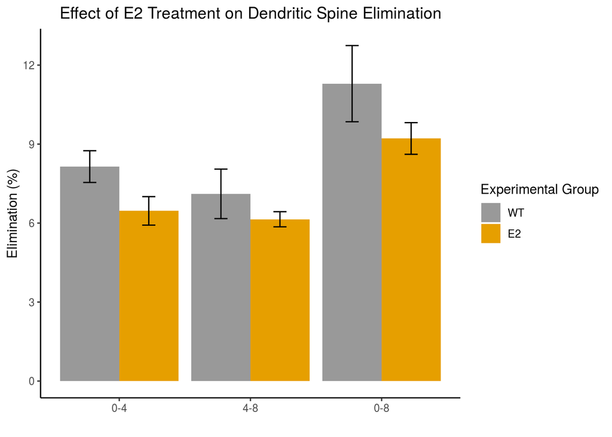

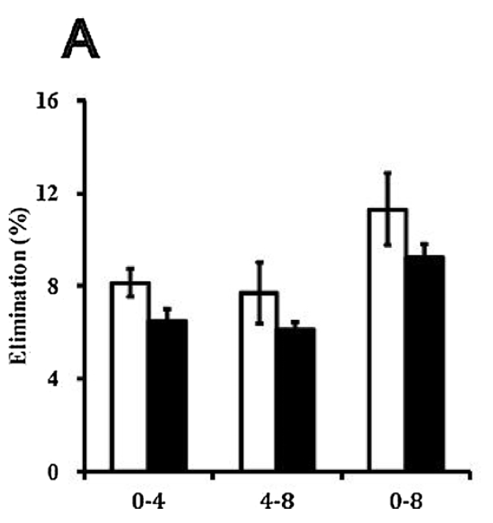

```r
data_summary <- function(data, varname, groupnames){
  require(plyr)
  summary_func <- function(x, col){
    c(mean = mean(x[[col]], na.rm = TRUE),
      se = sd(x[[col]], na.rm = TRUE) / sqrt(length(x[[col]])))
  }
  data_sum <- ddply(data, groupnames, .fun = summary_func, varname)
  data_sum <- rename(data_sum, c("mean" = varname))
  return(data_sum)
}

Fig2_SER_datsum <- data_summary(Fig2_data, varname = "SER", groupnames = c("Exp_Group", "Day"))
Fig2_SER_datsum$Exp_Group <- factor(Fig2_SER_datsum$Exp_Group, levels = c("WT", "E2"))
Fig2_SER <- ggplot(data = Fig2_SER_datsum, aes(x = Day, y = SER, fill = Exp_Group)) +
  geom_bar(stat = "identity", position = position_dodge()) +
  scale_fill_manual(values = c('#999999','#E69F00')) +
  scale_x_discrete(limits = c("0-4", "4-8", "0-8")) +
  xlab("") + ylab("Elimination (%)") +
  scale_color_grey() + theme_classic() +
  geom_errorbar(aes(ymin = SER - se, ymax = SER + se), width = .2,
                position = position_dodge(.9)) +
  labs(fill = "Experimental Group") +
  scale_y_continuous(breaks = seq(0, 15, len = 6)) +
  ggtitle("Effect of E2 Treatment on Dendritic Spine Elimination") +
  theme(plot.title = element_text(hjust = 0.5))

Fig2_SFR_datsum <- data_summary(Fig2_data, varname = "SFR", groupnames = c("Exp_Group", "Day"))
Fig2_SFR_datsum$Exp_Group <- factor(Fig2_SFR_datsum$Exp_Group, levels = c("WT", "E2"))
Fig2_SFR <- ggplot(data = Fig2_SFR_datsum, aes(x = Day, y = SFR, fill = Exp_Group)) +
  geom_bar(stat = "identity", position = position_dodge()) +
  scale_fill_manual(values = c('#999999','#E69F00')) +
  scale_x_discrete(limits = c("0-4", "4-8", "0-8")) +
  xlab("") + ylab("Formation (%)") +
  scale_color_grey() + theme_classic() +
  geom_errorbar(aes(ymin = SFR - se, ymax = SFR + se), width = .2,
                position = position_dodge(.9)) +
  labs(fill = "Experimental Group") +
  scale_y_continuous(breaks = seq(0, 15, len = 6)) +
  ggtitle("Effect of E2 Treatment on Dendritic Spine Formation") +
  theme(plot.title = element_text(hjust = 0.5))

Fig2_TSC_datsum <- data_summary(Fig2_data, varname = "TSC", groupnames = c("Exp_Group", "Day"))
Fig2_TSC_datsum$Exp_Group <- factor(Fig2_TSC_datsum$Exp_Group, levels = c("WT", "E2"))
Fig2_TSC <- ggplot(data = Fig2_TSC_datsum, aes(x = Day, y = TSC, fill = Exp_Group)) +
  geom_bar(stat = "identity", position = position_dodge()) +
  scale_fill_manual(values = c('#999999','#E69F00')) +
  scale_x_discrete(limits = c("0-4", "4-8", "0-8")) +
  xlab("") + ylab("Total Spine Number (%)") +
  scale_color_grey() + theme_classic() +
  geom_errorbar(aes(ymin = TSC - se, ymax = TSC + se), width = .2,
                position = position_dodge(.9)) +
  labs(fill = "Experimental Group") +
  coord_cartesian(ylim = c(84, 104)) +
  ggtitle("Effect of E2 Treatment on Total Spine Count") +
  theme(plot.title = element_text(hjust = 0.5))

Fig2_SER
```

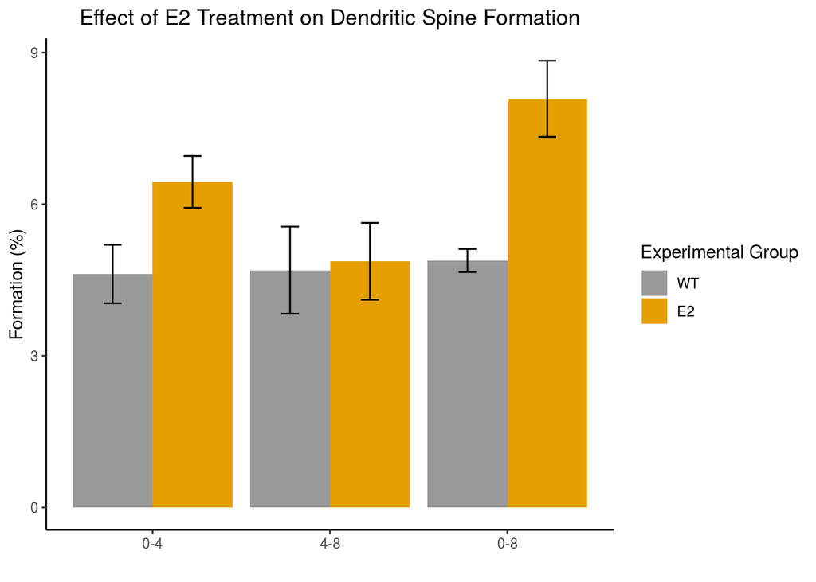

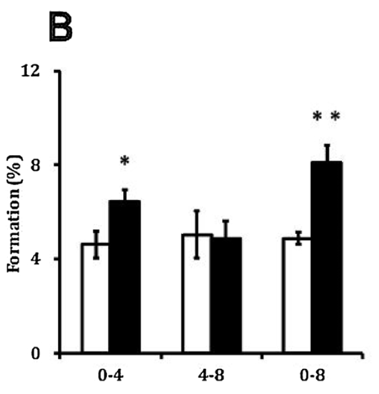

```r
Fig2_SFR
```

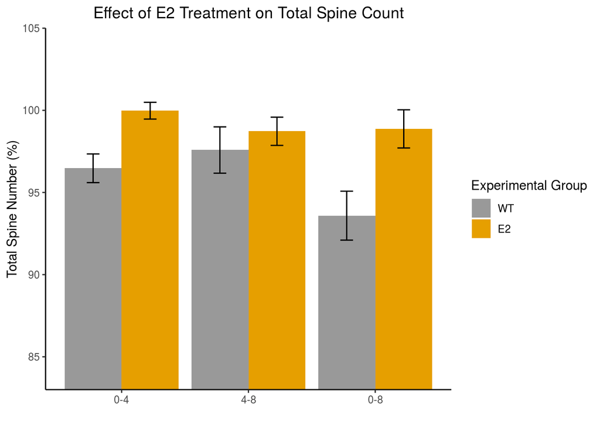

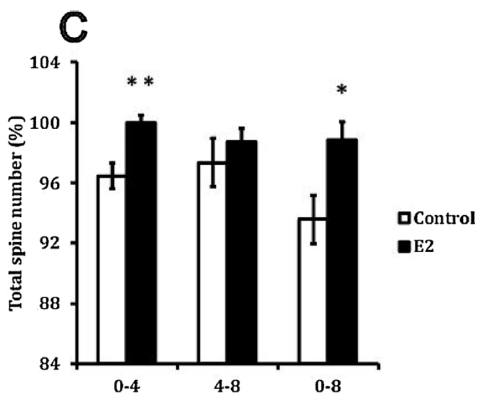

```r
Fig2_TSC
```

In observing these three pairs of images, my reanalysis of the authors’ data appeared to be successful and matched with Figure 2 of the manuscript.

## Discussion

```r
t.test(WT1$dT_total, WT2$dT_total)
```

```
##
##  Welch Two Sample t-test
##
## data:  WT1$dT_total and WT2$dT_total
## t = -1.5073, df = 10.659, p-value = 0.1608
## alternative hypothesis: true difference in means is not equal to 0
## 95 percent confidence interval:
##  -24.835032   4.692175
## sample estimates:
## mean of x mean of y
##  132.5000  142.5714
```

I think that the authors could have performed a repeated measures ANOVA to determine whether dendritic spine formation and elimination is also affected as a function of time post-E2 treatment. I feel like performing other statistical tests in addition to a Student’s t-test would help strengthen the paper and could lead to interesting discoveries.

Overall, I feel that working on this assignment has really helped strengthen my *R* skills. Given that this paper is in a similar research field that I am in, I can now see myself being able to use *R* in my own research and data analysis. I found that the trickiest parts of this data replication assignment was replicating the graphs in Figure 2. This required some reorganization of the raw data file and creation of new data frames that I was unfamiliar with. I also learned a lot about many of the difficult functionalities of {ggplot2} and what makes it such a versatile package.